# Prerergistration

Julio Martinez

12/6/2021

## Introduction

For this project I will re-implement SIPS as well as run Plan Recognition as Planning (PRP) as a baseline.

I wil run SIPS and PRP on four domains:

- **Doors, Keys, and Gems**: A gridworld with locks, keys, and gems (the goals) where an agent has one underlying gem goal.
- **Taxi**: A gridworld where a taxi is tasked with transporting a passenger from one grid cell to another gridcell.
- **Block Words**: A world where blocks are associated with a letter and where the goals are to build block towers that spell one of the five possible words.
- **Intrusion Detection**: A domain where an agent is tasked to perform a cyber attack on up to a set of 10 servers from a set of 20 possible goals, each with a corresponding set of attacks.

Reproducibility will entail:

1. t-tests on the mean and std deviations of the probability of the true goal given a history of observations of the original results and the new results from running the reimplementged SIPS and off the shelf PRP for several goals and intial states under all four domains listed above for 1st, 2nd, and 3rd quartiles of the trajectories for observed optimal plans and suboptimal plans with backtracking.
2. t-tests on the mean and std deviation of the proportion of time the probability of the true goal leads top1 accuracy (true goal has value in the predicted distribution) for the original data and the reimplemented SIPS and off the shelf PRP for several goals and intial states under all four domains listed above for 1st, 2nd, and 3rd quartiles of the trajectories for observed optimal plans and suboptimal plans with backtracking.
3. t-tests on the mean and std deviation of the number of states visited for the original data and the reimplemented SIPS and off the shelf PRP for several goals and initial states under all four domains listed above for 1st, 2nd, and 3rd quartiles of the trajectories for observed optimal plans and suboptimal plans with backtracking.
4. run pearson correlations over the trajectory of SIPS and PRP to human judgements on the keys, doors, and gems domain for a suboptimal case with backtracking listed as shown in figure 1 in the original paper.

### Figures

The figures and tables below contain the original results from running SIPS and PRP in the paper and the ones mentioned above are the ones I am aiming to reproduce. My plan is to reproduce all results in the tables and the trajectory figures but restricted to SIPS and PRP method (will not reproduce BIRL-U and BIRL-O) for tabes S1 and S2. For tabes S3 and S4 I will only reproduce the last column (mean of N and its standard deviation) for SIPS and PRP for all domains.

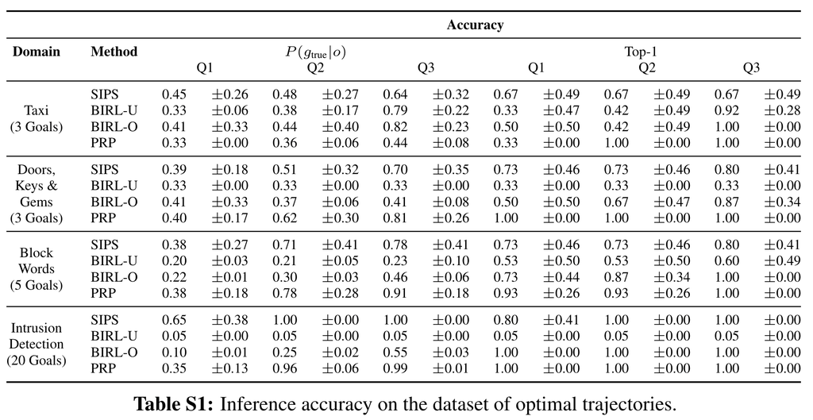

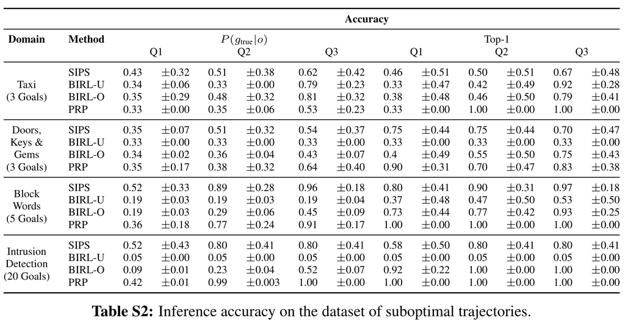

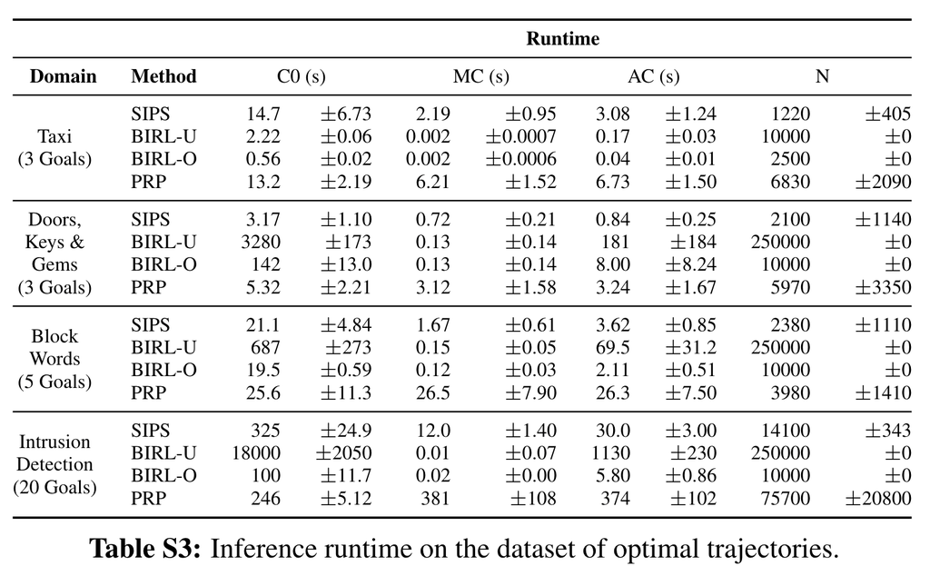

Efficiency Under Optimal Plans

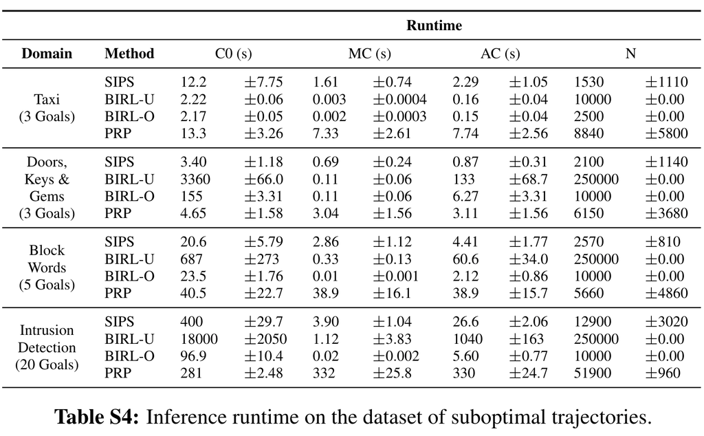

Efficiency Under Suboptimal Plans

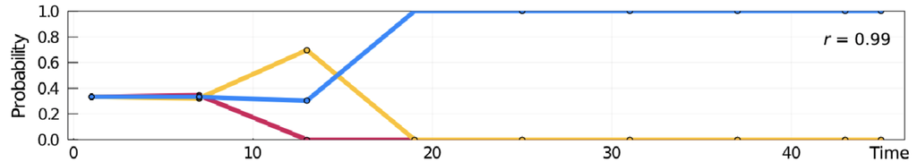

SIPS Inferences

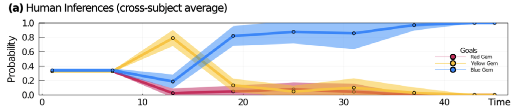

Human Trajectories

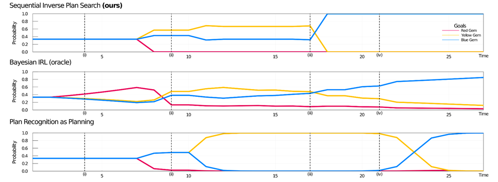

Qualitative Comparisons

### Links

Project repository (on Github): [repository](https://github.com/psych251/zhi-xuan2020)

Original paper (as hosted in your repo): [original paper](https://github.com/psych251/zhi-xuan2020/blob/main/original_paper/2006.07532.pdf)

## Methods

The reimplementation of SIPS for online bayesian search will be based on the algorithm pseudocode provided in the paper and is shown below.

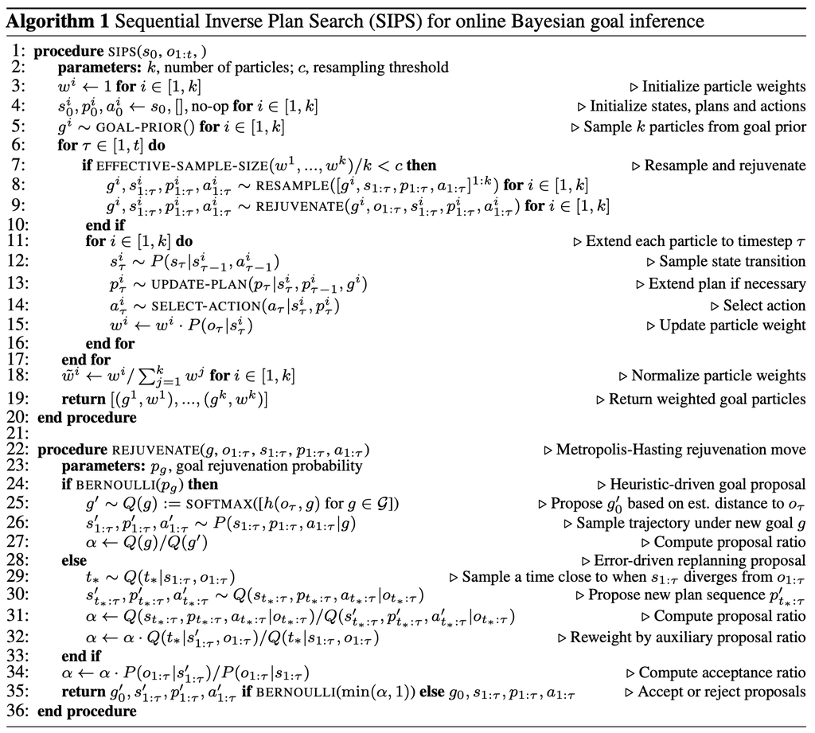

Algorithm Pseudocode for a SIPS Observer.